# HW4_part1

資料來源:  
教育https://data.gov.tw/dataset/35960  
年齡https://data.gov.tw/dataset/36105  
婚姻https://data.gov.tw/dataset/35917

```r
Edu = read.csv('education.csv')
Mar = read.csv('marriage.csv')
Age = read.csv('age.csv')
library(ggplot2)
library(reshape2)
library(gridExtra)
```

### 觀察失業率

1.教育程度

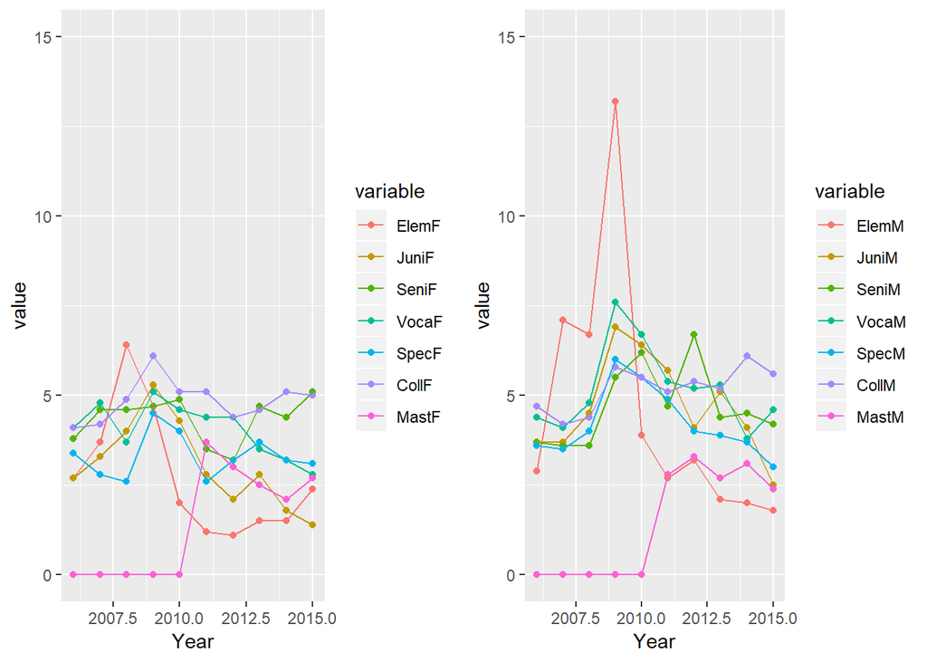

```r
EduF <- Edu[,c("Year","ElemF","JuniF","SeniF", "VocaF","SpecF","CollF","MastF")]
EduF <- melt(EduF, id.vars="Year")
EduM <- Edu[,c("Year","ElemM","JuniM","SeniM", "VocaM","SpecM","CollM","MastM")]
EduM <- melt(EduM, id.vars="Year")

plotF1 <- ggplot(EduF, aes(Year,value, col=variable)) +
  geom_point() +
  geom_line() +
  ylim(0, 15)
plotM1 <- ggplot(EduM, aes(Year,value, col=variable)) +
  geom_point() +
  geom_line()+
  ylim(0, 15)
grid.arrange(plotF1, plotM1, ncol=2)
```

2.年齡

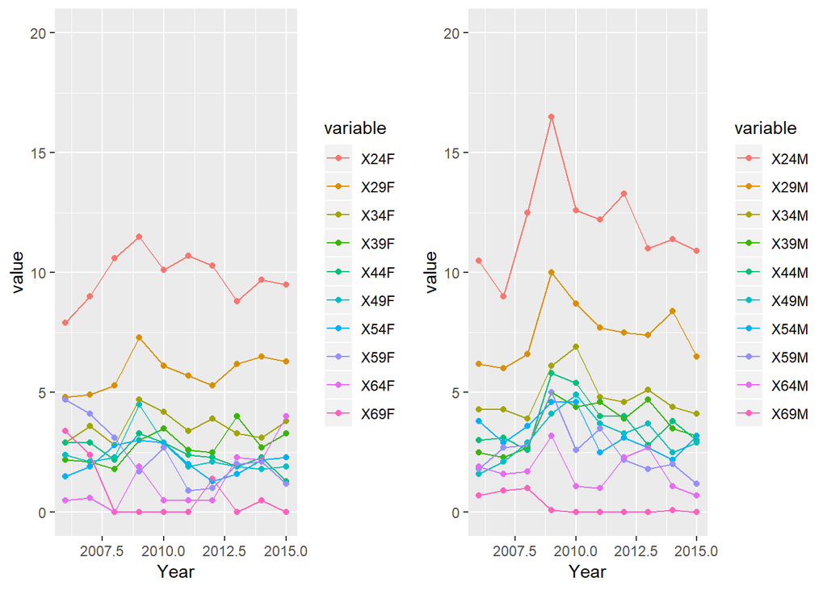

```r
AgeF <- Age[,c("Year","X24F","X29F","X34F", "X39F","X44F","X49F","X54F","X59F","X64F","X69F")]
AgeF <- melt(AgeF, id.vars="Year")
AgeM <- Age[,c("Year","X24M","X29M","X34M", "X39M","X44M","X49M","X54M","X59M","X64M","X69M")]
AgeM <- melt(AgeM, id.vars="Year")

plotF2 <- ggplot(AgeF, aes(Year,value, col=variable)) +
  geom_point() +
  geom_line() +
  ylim(0, 20)
plotM2 <- ggplot(AgeM, aes(Year,value, col=variable)) +
  geom_point() +
  geom_line() +
  ylim(0, 20)
grid.arrange(plotF2, plotM2, ncol=2)
```

3.婚姻

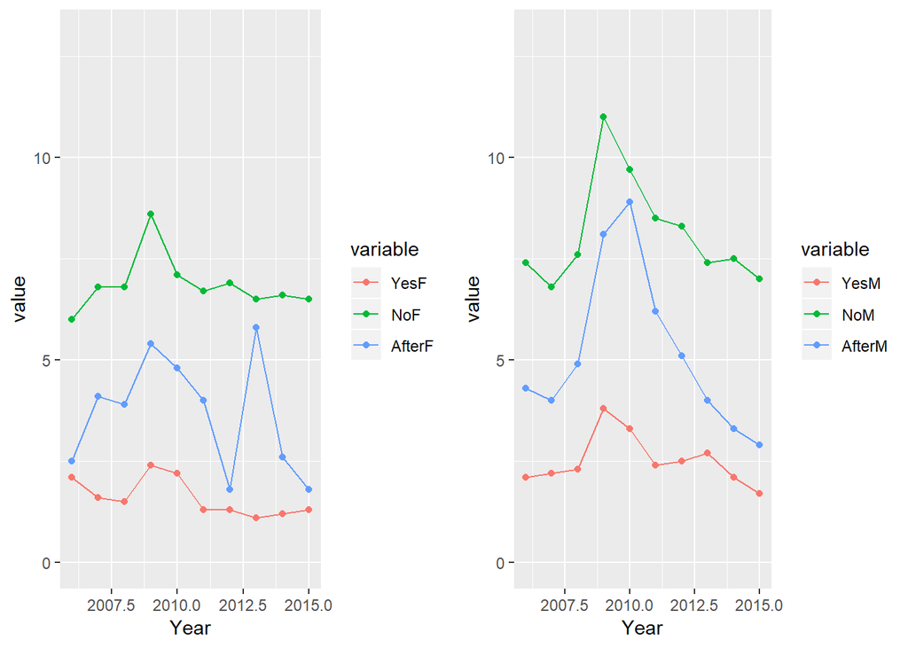

```r
MarF <- Mar[,c("Year","YesF","NoF","AfterF")]
MarF <- melt(MarF, id.vars="Year")
MarM <- Mar[,c("Year","YesM","NoM","AfterM")]
MarM <- melt(MarM, id.vars="Year")

plotF3 <- ggplot(MarF, aes(Year,value, col=variable)) +
  geom_point() +
  geom_line()+
  ylim(0, 13)
plotM3 <- ggplot(MarM, aes(Year,value, col=variable)) +
  geom_point() +
  geom_line() +
  ylim(0, 13)
grid.arrange(plotF3, plotM3, ncol=2)
```

看起來無論是用什麼指標分類，男性的失業率普遍都比相同標準的女性要高

### PartA.性別vs失業率

1.將這10年間的各分類男女失業率整理成新dataframe: GenderDf

```r
year = c(2006:2015)
gender = c(rep("M", each=200), rep("F", each=200))
catagory = c(rep("Elem", each=10), rep("Juni", each=10), rep("Seni", each=10), rep("Voca", each=10), rep("Spec", each=10), rep("Coll", each=10), rep("Mast", each=10), rep("24", each=10), rep("29", each=10), rep("34", each=10), rep("39", each=10), rep("44", each=10), rep("49", each=10), rep("54", each=10), rep("59", each=10), rep("64", each=10), rep("69",each=10), rep("No", each=10), rep("Yes", each=10), rep("After", each=10))
rate = c(EduM$value, AgeM$value, MarM$value, EduF$value, AgeF$value, MarF$value)
GenderDf <- data.frame(year,gender,catagory, rate)
```

2.畫圖觀察男女失業率─盒形圖，並計算信賴區間

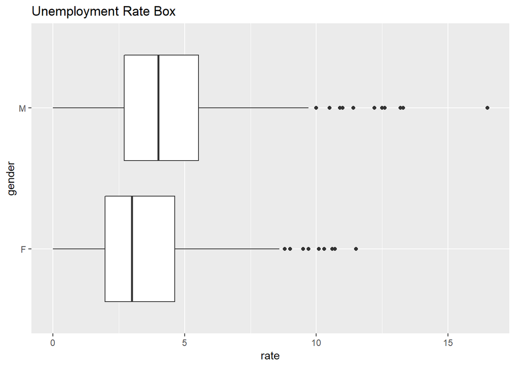

```r
ggplot(data = GenderDf, aes(x = gender, y = rate)) +
 geom_boxplot() + coord_flip() +
 labs( y = 'rate', x = 'gender',
       title = 'Unemployment Rate Box')
```

(95%信賴區間)

```r
with(GenderDf,
     tapply(rate, gender,
     function(x)
       c(mean(x) + c(-2, 2) * sd(x)/sqrt(length(x)))))
```

```
## $F
## [1] 3.138404 3.786596
##
## $M
## [1] 4.026428 4.833572
```

### 以下用 t-test 檢驗性別是否影響失業率

```r
t.test(rate ~ gender, data = GenderDf)
```

```
##
##  Welch Two Sample t-test
##
## data:  rate by gender
## t = -3.7384, df = 380.28, p-value = 0.0002136
## alternative hypothesis: true difference in means is not equal to 0
## 95 percent confidence interval:
##  -1.4763569 -0.4586431
## sample estimates:
## mean in group F mean in group M
##          3.4625          4.4300
```

(假設變異數相同)

```r
t.test(rate ~ gender, data = GenderDf, var.equal = TRUE)
```

```
##
##  Two Sample t-test
##
## data:  rate by gender
## t = -3.7384, df = 398, p-value = 0.0002123
## alternative hypothesis: true difference in means is not equal to 0
## 95 percent confidence interval:
##  -1.4762846 -0.4587154
## sample estimates:
## mean in group F mean in group M
##          3.4625          4.4300
```

### PartB.教育程度vs失業率

1.觀察教育程度是否與失業率有關

```r
library(Hmisc)
library(dplyr)
Gender2 <- GenderDf[c(1:70, 201:270),]
Gender2$catagory <- factor(Gender2$catagory,
                       levels = c('Elem','Juni','Seni','Voca','Spec','Coll','Mast'))
tapply(Gender2$rate, Gender2$catagory, mean)
```

```
##  Elem  Juni  Seni  Voca  Spec  Coll  Mast
## 3.640 3.860 4.530 4.625 3.760 5.030 1.415
```

2.畫圖

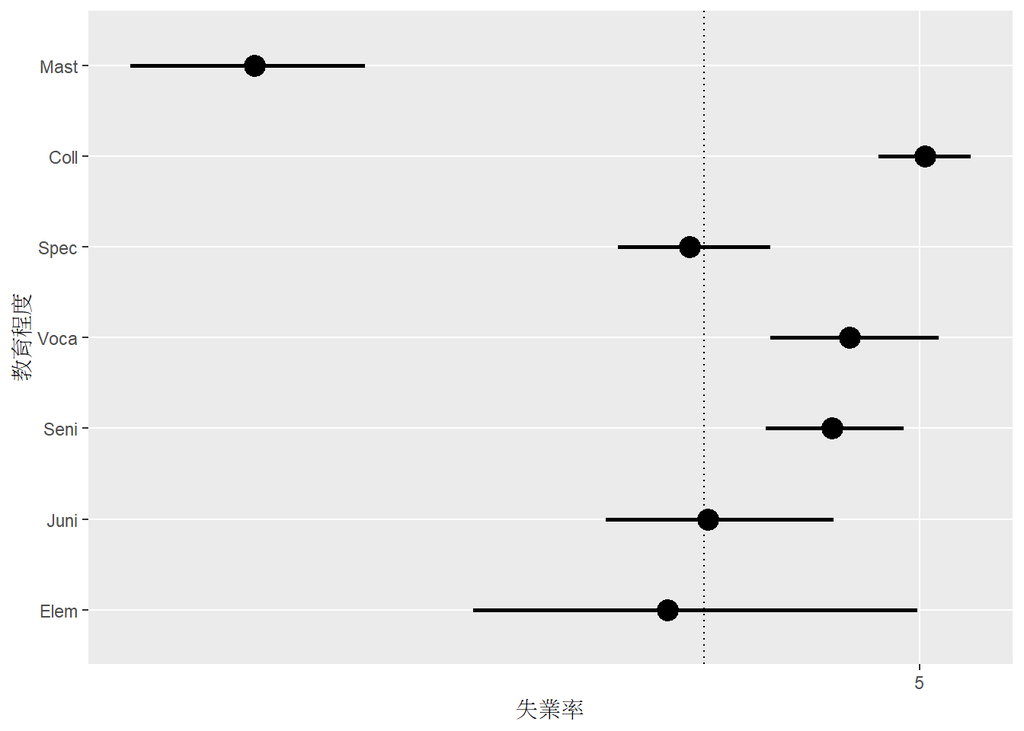

```r
ggplot(data = Gender2,
       aes(x = catagory, y = rate)) +
  stat_summary(fun.data = 'mean_cl_boot', size = 1) +
  scale_y_continuous(breaks = seq(0, 20, by = 5)) +
  geom_hline(yintercept = mean(Gender2$rate) ,
             linetype = 'dotted') +
  labs(x = '教育程度', y = '失業率') +
  coord_flip()
```

### ANOVA檢驗

```r
anova(m1 <- lm(rate ~ catagory, data =Gender2))
```

```
## Analysis of Variance Table
##
## Response: rate
##            Df Sum Sq Mean Sq F value    Pr(>F)
## catagory    6 168.72 28.1193    12.3 5.547e-11 ***
## Residuals 133 304.05  2.2861
## ---
## Signif. codes:  0 '***' 0.001 '**' 0.01 '*' 0.05 '.' 0.1 ' ' 1
```

### 推測學歷與失業率的關係會受年分改變影響，畫圖觀察

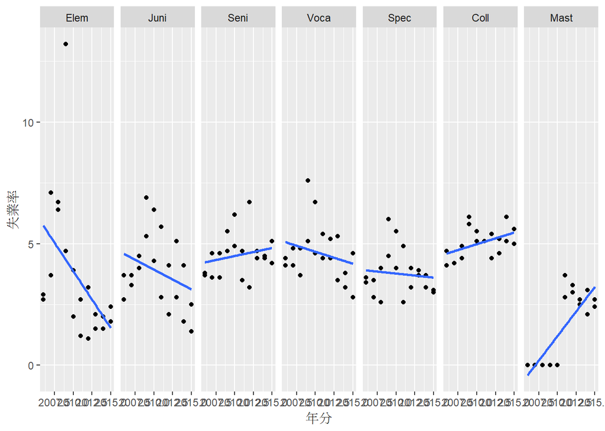

```r
ggplot(data = Gender2,
       aes(group = catagory,
          y = rate, x = year)) +
  geom_point() +
  stat_smooth(method = 'lm', se = F) +
  stat_smooth(aes(group = catagory,
          y = rate, x = year),
          method = 'lm', se = F) +
  facet_grid( . ~  catagory) +
  labs(x = '年分', y = '失業率')
```

1.用ANOVA檢驗假設是否正確─將年份加入模型

```r
anova(m2 <- update(m1, . ~ . +
            year, data = Gender2))
```

```
## Analysis of Variance Table
##
## Response: rate
##            Df  Sum Sq Mean Sq F value    Pr(>F)
## catagory    6 168.716 28.1193 12.2429 6.393e-11 ***
## year        1   0.876  0.8755  0.3812     0.538
## Residuals 132 303.175  2.2968
## ---
## Signif. codes:  0 '***' 0.001 '**' 0.01 '*' 0.05 '.' 0.1 ' ' 1
```

2.或許不是學歷而是年分

```r
anova(m3 <- update(m2, . ~ . - catagory,  data = Gender2))
```

```
## Analysis of Variance Table
##
## Response: rate
##            Df Sum Sq Mean Sq F value Pr(>F)
## year        1   0.88  0.8755   0.256 0.6137
## Residuals 138 471.89  3.4195
```

### 將ANOVA結果做成圖表

1.計算需要的數據

```r
res_lm <- lapply(list(m1, m2, m3), summary)
(res_lm[[2]]$r.sq - res_lm[[3]]$r.sq)/res_lm[[2]]$r.sq
```

```
## [1] 0.9948374
```

a.控制年分下，教育程度的影響

```r
anova(m3, m2)
```

```
## Analysis of Variance Table
##
## Model 1: rate ~ year
## Model 2: rate ~ catagory + year
##   Res.Df    RSS Df Sum of Sq      F    Pr(>F)
## 1    138 471.89
## 2    132 303.18  6    168.72 12.243 6.393e-11 ***
## ---
## Signif. codes:  0 '***' 0.001 '**' 0.01 '*' 0.05 '.' 0.1 ' ' 1
```

b.控制教育程度下，年份的影響

```r
(res_lm[[2]]$r.sq - res_lm[[1]]$r.sq)/res_lm[[1]]$r.sq
```

```
## [1] 0.005189391
```

```r
anova(m1, m2)
```

```
## Analysis of Variance Table
##
## Model 1: rate ~ catagory
## Model 2: rate ~ catagory + year
##   Res.Df    RSS Df Sum of Sq      F Pr(>F)
## 1    133 304.05
## 2    132 303.18  1   0.87553 0.3812  0.538
```

2.畫圖

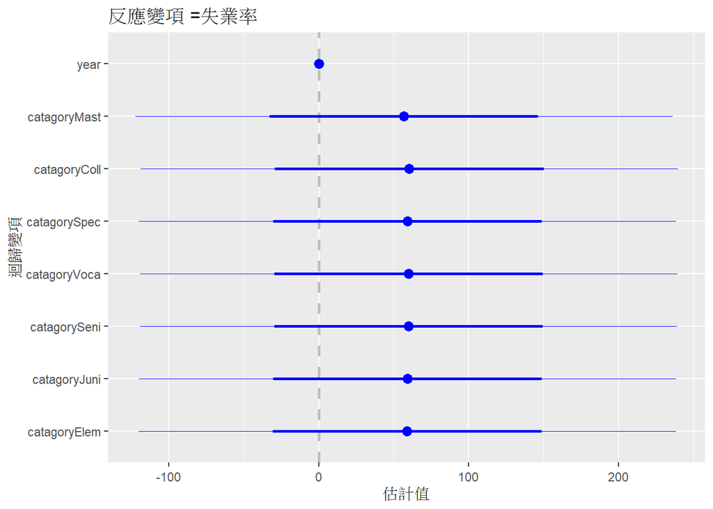

```r
library(coefplot)

m2 <- lm(rate ~ catagory+year- 1,
         data = Gender2)
coefplot(m2, xlab = '估計值', ylab = '迴歸變項', title = '反應變項 =失業率')
```

3.把預測值、殘差與影響度放進資料

```r
fit_m2 <- data.frame(Gender2[, c(4, 3, 1)], fitted = fitted(m2), resid = resid(m2),
                     infl = influence(m2)$hat )
```

4.依教育程度疊合觀測值與預測值

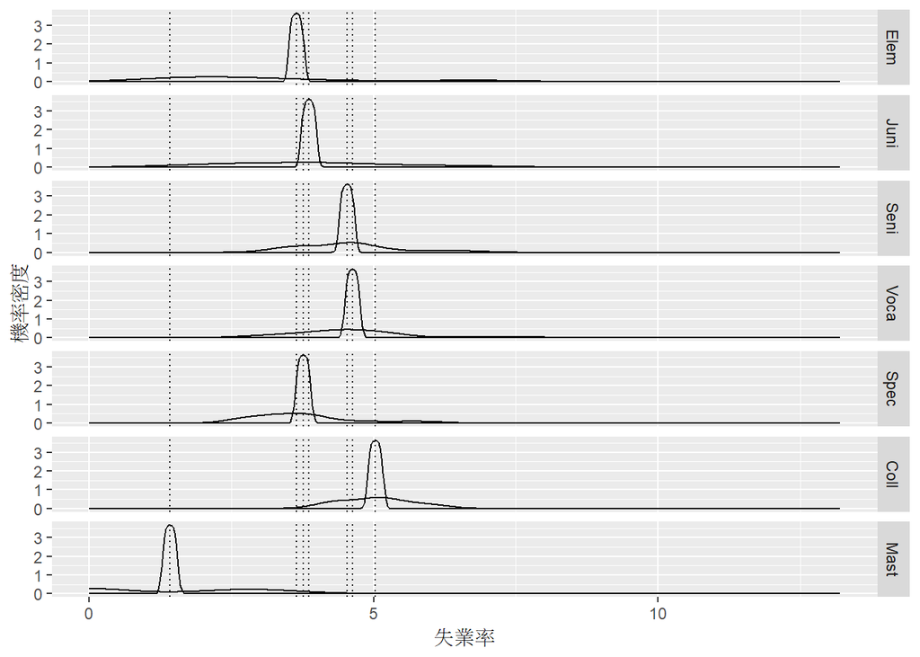

```r
ggplot(data = fit_m2, aes(x = rate, group = catagory )) +
 stat_density(geom = 'path', position = 'identity') +
 stat_density(geom = 'path', position = 'identity', aes(x = fitted)) +
 geom_vline(xintercept = c(with(Gender2, tapply(rate,catagory, mean))), linetype = 'dotted')+
 facet_grid(catagory ~ .) +
 scale_x_continuous(breaks = seq(0, 20, by = 5))+
 labs(x = '失業率', y = '機率密度')
```

5.看殘差分配，依教育程度，檢視常態與變異數同質假設

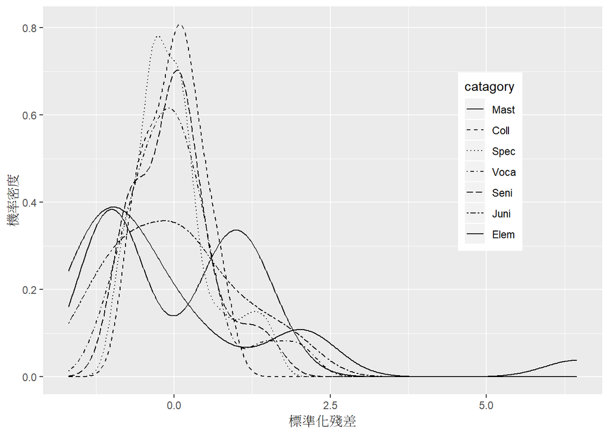

```r
ggplot(data = fit_m2, aes(x = scale(resid)), group = catagory ) +
 stat_density(geom = 'path', position = 'identity', aes(linetype = catagory)) +
 scale_linetype_manual(values = 7:1) +
 guides(linetype = guide_legend(reverse = TRUE)) +
 labs(x = '標準化殘差', y = '機率密度') +
 theme(legend.position = c(.8, .6))
```

6.看殘差Q-Q 圖，依教育程度。檢視常態假設

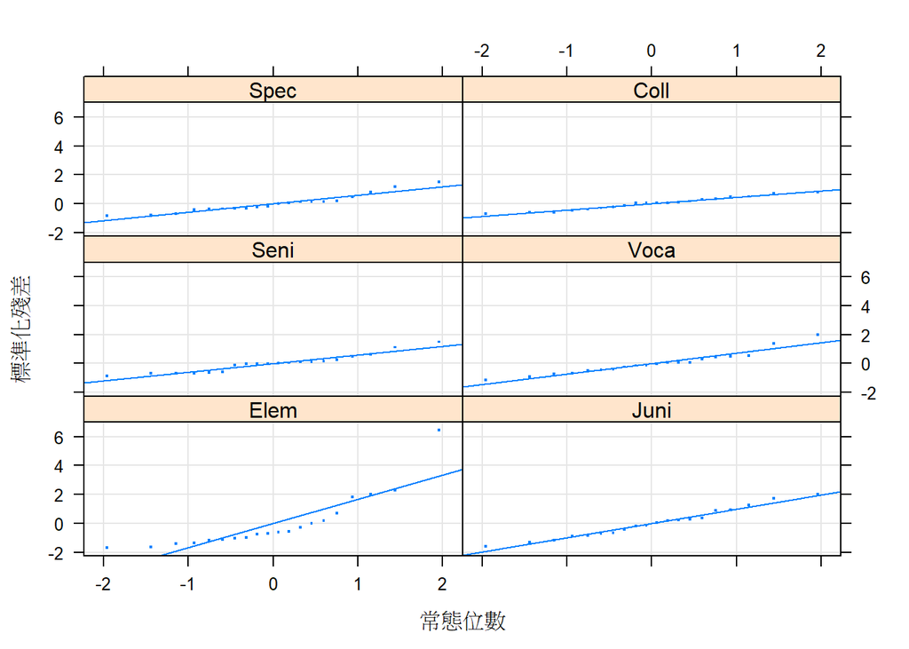

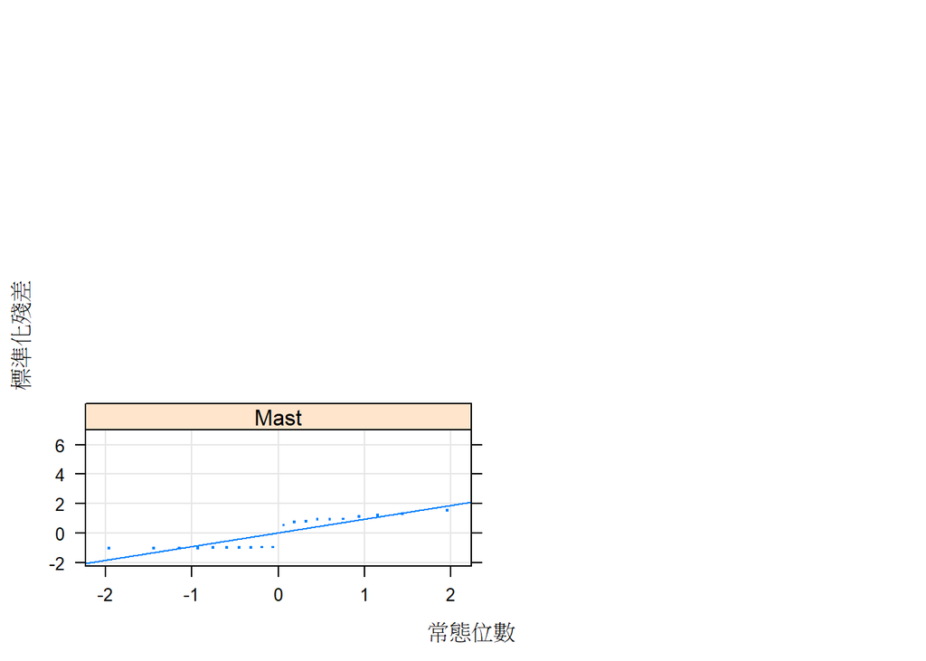

```r
library(lattice)
qqmath(~ scale(resid) | catagory, data = fit_m2, type = c('p', 'g', 'r'),
       xlab = '常態位數', ylab = '標準化殘差', layout = c(2, 3),
       pch = '.', cex = 2)
```

7.看預測值與殘差的散佈圖，檢查線性與等分散假設

```r
library(MASS)
```

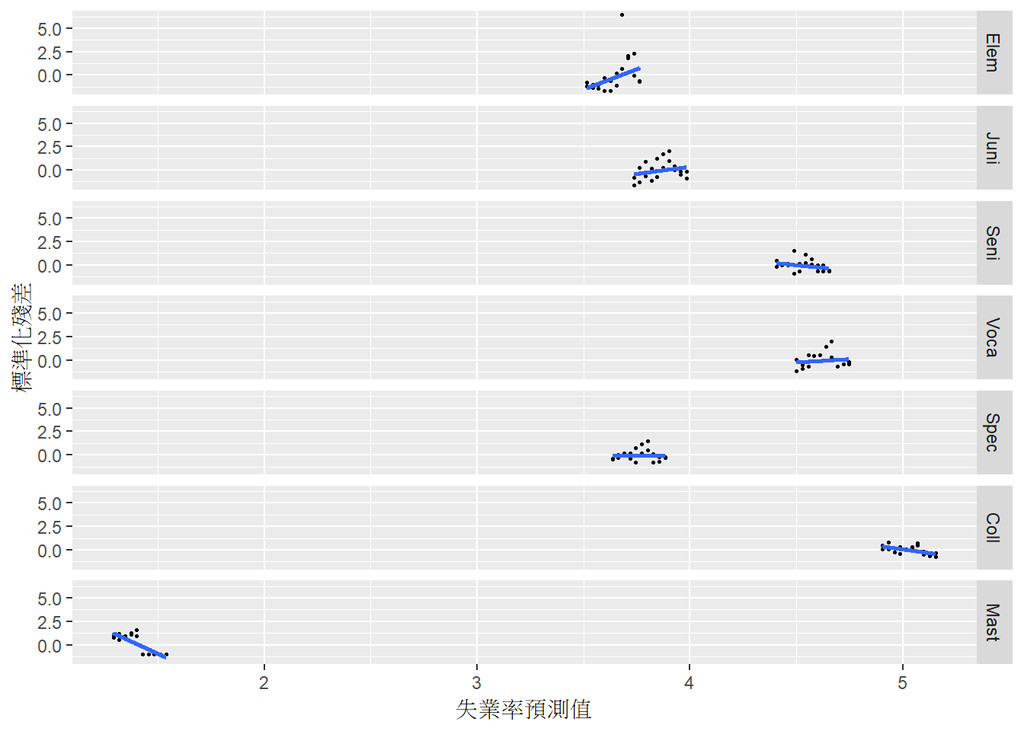

```r
ggplot(data = fit_m2, aes(x = fitted, y = scale(resid), group = catagory )) +
  geom_point(pch = 20, size = 1) +
  stat_smooth(method = 'rlm', se = F) +
  facet_grid(catagory ~ .) +
  labs(x = '失業率預測值', y = '標準化殘差')
```

8.呈現影響值（影響估計結果過大的值）與標準化殘差

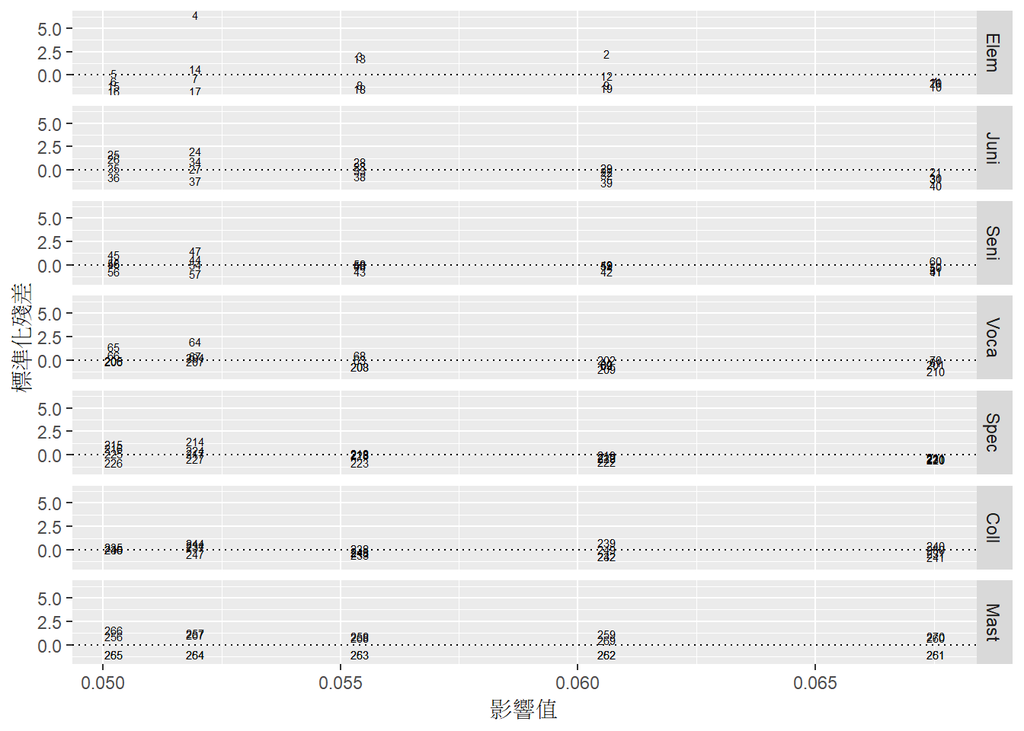

```r
ggplot(data = fit_m2, aes(x = infl, y = scale(resid), group = catagory)) +
 geom_text(aes(label = rownames(fit_m2)), cex = 2) +
 geom_hline(yintercept = 0, linetype = 'dotted') +
 facet_grid(catagory ~ .) +
 labs(x = '影響值', y = '標準化殘差')
```

9.看影響值

```r
summary(influence(m2)$hat)
```

```
##    Min. 1st Qu.  Median    Mean 3rd Qu.    Max.
## 0.05022 0.05195 0.05541 0.05714 0.06061 0.06753
```

### Part C.分析資料集當中的其他變項是否和失業率有關

```r
age = c(rep(24, each=10),rep(29, each=10), rep(34,each=10), rep(39,each=10), rep(44,each=10), rep(49,each=10), rep(54,each=10), rep(59,each=10),rep(64,each=10),rep(69,each=10))
rate2 = c(AgeF$value, MarF$value)
Gender3 <- data.frame(rate, age, year)
```

1.檢視基本統計量

```r
colMeans(Gender3)
```

```
##       rate        age       year
##    3.94625   46.50000 2010.50000
```

2.呈現兩兩散佈圖

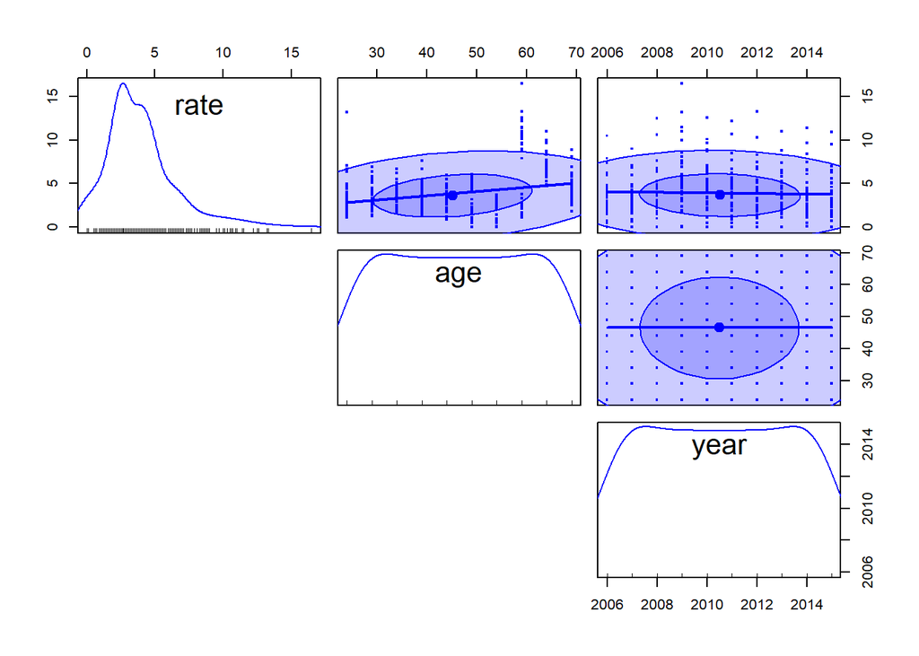

```r
library(heplots)
scatterplotMatrix(~ rate + age + year, data= Gender3,
  pch = '.', cex = 3, smooth = FALSE, reg.line = FALSE, ellipse = TRUE,
  diagonal = 'none', lower.panel = NULL)
```

3.使用corrplot，以圖形顯示相關性的大小

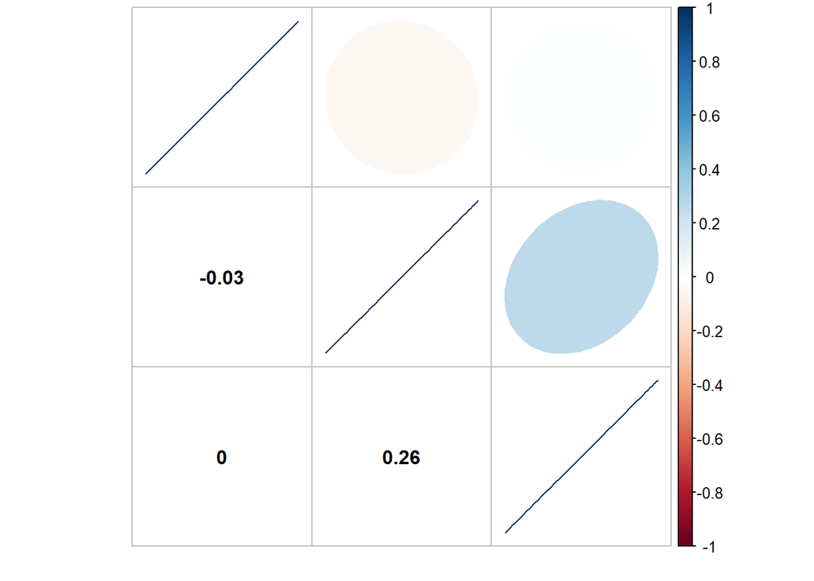

```r
library(corrplot)
corrplot(cor(Gender3), method = 'ellipse', order = 'hclust', addrect =5,
         type = 'upper', tl.pos = 'n')
corrplot(cor(Gender3), add = TRUE, type = 'lower', method = 'number',
         order = 'hclust', col = 'black', diag = FALSE, tl.pos = 'n', cl.pos = 'n')
```

```r
summary(m4 <- lm(rate ~ age + year, data = Gender3))
```

```
##
## Call:
## lm(formula = rate ~ age + year, data = Gender3)
##
## Residuals:
##    Min     1Q Median     3Q    Max
## -4.443 -1.526 -0.242  1.178 11.912
##
## Coefficients:
##              Estimate Std. Error t value Pr(>|t|)
## (Intercept) 64.208829  89.028334   0.721    0.471
## age          0.047639   0.008856   5.379 1.28e-07 ***
## year        -0.031076   0.044281  -0.702    0.483
## ---
## Signif. codes:  0 '***' 0.001 '**' 0.01 '*' 0.05 '.' 0.1 ' ' 1
##
## Residual standard error: 2.544 on 397 degrees of freedom
## Multiple R-squared:  0.06901,    Adjusted R-squared:  0.06432
## F-statistic: 14.71 on 2 and 397 DF,  p-value: 6.847e-07
```

5.看看效果如何

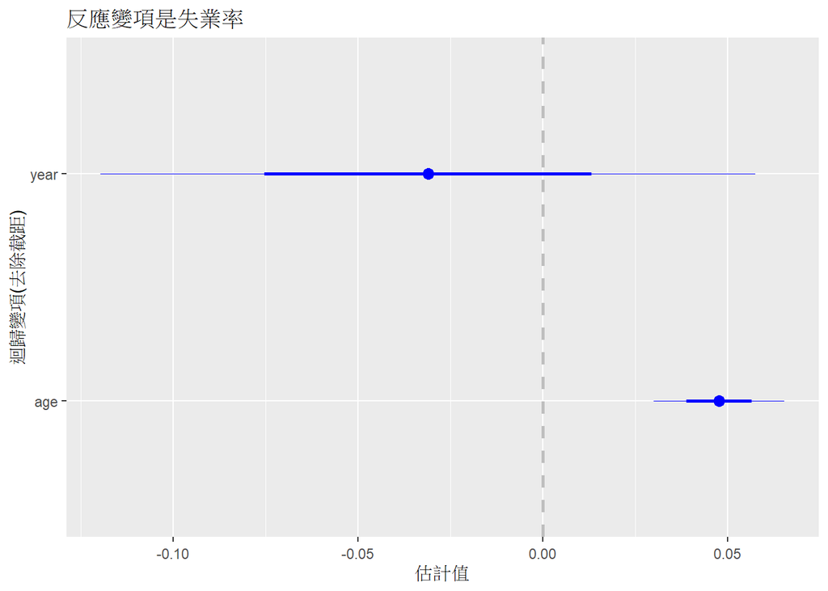

```r
coefplot(m4, predictors = c('rate', 'age',
                            'year'),
 xlab = '估計值', ylab = '迴歸變項(去除截距)', title = '反應變項是失業率')
```

```r
library(effects)
```

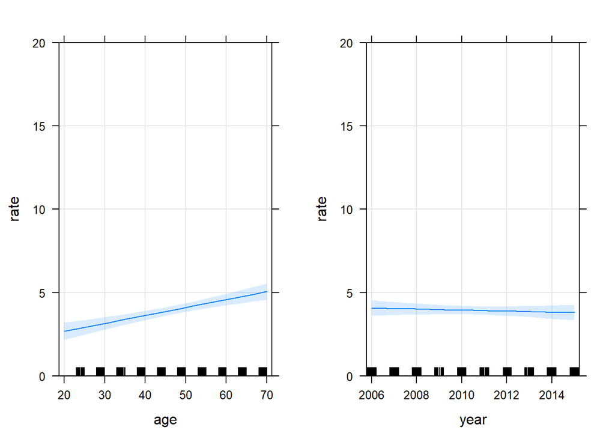

```r
plot(allEffects(m4), main = '', ylim = c(0, 20), grid = T)
```

6.利用 lm.beta 套件，計算標準化迴歸係數

```r
library(lm.beta)
summary(lm.beta(m4))
```

```
##
## Call:
## lm(formula = rate ~ age + year, data = Gender3)
##
## Residuals:
##    Min     1Q Median     3Q    Max
## -4.443 -1.526 -0.242  1.178 11.912
##
## Coefficients:
##              Estimate Standardized Std. Error t value Pr(>|t|)
## (Intercept) 64.208829     0.000000  89.028334   0.721    0.471
## age          0.047639     0.260492   0.008856   5.379 1.28e-07 ***
## year        -0.031076    -0.033984   0.044281  -0.702    0.483
## ---
## Signif. codes:  0 '***' 0.001 '**' 0.01 '*' 0.05 '.' 0.1 ' ' 1
##
## Residual standard error: 2.544 on 397 degrees of freedom
## Multiple R-squared:  0.06901,    Adjusted R-squared:  0.06432
## F-statistic: 14.71 on 2 and 397 DF,  p-value: 6.847e-07
```

7.看看控制年齡後，年分的效果

```r
summary(m5 <- update(m4, . ~ . - year , data = Gender3))
```

```
##
## Call:
## lm(formula = rate ~ age, data = Gender3)
##
## Residuals:
##     Min      1Q  Median      3Q     Max
## -4.3035 -1.5926 -0.2126  1.2133 11.9583
##
## Coefficients:
##             Estimate Std. Error t value Pr(>|t|)
## (Intercept) 1.731018   0.430734   4.019 7.00e-05 ***
## age         0.047639   0.008851   5.383 1.26e-07 ***
## ---
## Signif. codes:  0 '***' 0.001 '**' 0.01 '*' 0.05 '.' 0.1 ' ' 1
##
## Residual standard error: 2.542 on 398 degrees of freedom
## Multiple R-squared:  0.06786,    Adjusted R-squared:  0.06551
## F-statistic: 28.97 on 1 and 398 DF,  p-value: 1.257e-07
```

```r
anova(m5, m4)
```

```
## Analysis of Variance Table
##
## Model 1: rate ~ age
## Model 2: rate ~ age + year
##   Res.Df    RSS Df Sum of Sq      F Pr(>F)
## 1    398 2572.1
## 2    397 2568.9  1    3.1868 0.4925 0.4832
```

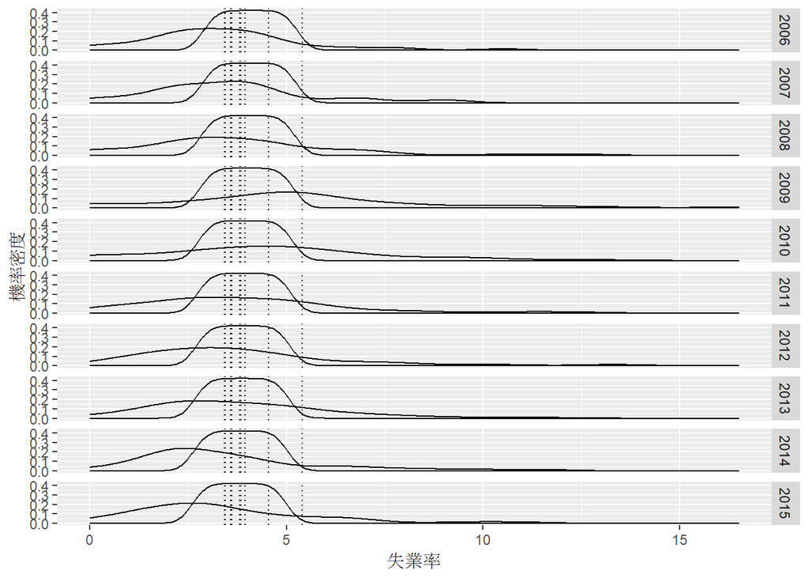

```r
m5 <- lm(rate ~ age + year, data = Gender3)
fit_m5 <- data.frame(Gender3[, c(1, 2, 3)], fitted = fitted(m5), resid = resid(m5), infl = influence(m5)$hat)

ggplot(data = fit_m5, aes(x = rate, group = year )) +
 stat_density(geom = 'path', position = 'identity') +
 stat_density(geom = 'path', position = 'identity', aes(x = fitted)) +
 geom_vline(xintercept = c(with(Gender3, tapply(rate, year, mean))), linetype = 'dotted')+
 facet_grid(year ~ .) +
 scale_x_continuous(breaks = seq(0, 20, by = 5))+
 labs(x = '失業率', y = '機率密度')
```